# house_value_project_final

Marco Zuñiga

6/27/2021

# House Value Project

El proposito del siguiente notebook es analizar y crear un modelo de regresion para predecir el valor `median_house_value`. La data utilizada es de un censo aplicado en el estado de California. El Dataset esta dividido por bloque. Y contiene los siguientes atributos: - `Latitude` - `Longitud` - `housing_median_age`: Contiene la media del grupo de casas de las cuales se obtuvo información. - `total_rooms`: Total de habitaciones registrados dentro del bloque. - `total_bedroom`s: Total de dormitorios registrados dentro del bloque. - `population`: Población total del bloque. - `households`: Número total de hogares, un grupo de personas que residen dentro de una unidad de hogar, para un bloque. - median_income: Ingreso promedio para hogares dentro de un bloque de casas (medido en decenas de miles de dólares estadounidenses). - `median_house_value`: Valor medio de la vivienda para hogares dentro de un bloque (medido en dólares estadounidenses). - `ocean_proximity`: Ubicación de la casa respecto del océano/mar.

#### Variation Reduce Features.

```r
library("data.table")
library("dplyr")
```

```r
library("ggplot2")
library("kableExtra")
library("reshape2")
library("caret")
library("car")
library("gridExtra")
library("readr")
library(PerformanceAnalytics)
library(BBmisc)
```

## EDA

### Import Data

```
## Rows: 14,303
## Columns: 10
## $ longitude          <dbl> -122.29, -121.46, -121.46, -117.81, -118.25, -117.6~
## $ latitude           <dbl> 37.81, 38.65, 38.55, 33.67, 33.94, 33.60, 37.73, 34~
## $ housing_median_age <dbl> 26, 8, 52, 24, 44, 25, 45, 41, 38, 7, 43, 34, 37, 3~
## $ total_rooms        <dbl> 768, 3746, 2094, 3930, 1463, 3164, 1528, 1240, 1696~
## $ total_bedrooms     <dbl> 152, 767, 463, 661, 312, 449, 291, 320, 301, 386, 5~
## $ population         <dbl> 392, 2161, 1364, 1831, 940, 1517, 801, 711, 985, 93~
## $ households         <dbl> 127, 744, 407, 616, 312, 453, 287, 304, 278, 355, 4~
## $ median_income      <dbl> 1.7719, 3.2039, 1.2235, 6.3767, 2.3333, 6.7921, 1.2~
## $ median_house_value <dbl> 82500, 103400, 68500, 269000, 99800, 266000, 84700,~
## $ ocean_proximity    <chr> "NEAR BAY", "INLAND", "INLAND", "<1H OCEAN", "<1H O~
```

```
## Rows: 143
## Columns: 10
## $ longitude          <dbl> -121.29, -119.19, -122.21, -117.92, -122.86, -122.6~
## $ latitude           <dbl> 38.90, 36.34, 37.48, 33.63, 39.08, 38.40, 34.14, 34~
## $ housing_median_age <dbl> 45, 33, 20, 24, 24, 32, 50, 52, 5, 50, 44, 32, 27, ~
## $ total_rooms        <dbl> 2019, 2199, 505, 1562, 3127, 2826, 3657, 983, 5764,~
## $ total_bedrooms     <dbl> 394, 403, 216, 441, 674, 627, 708, 246, 996, 588, 6~
## $ population         <dbl> 1104, 1245, 326, 696, 1015, 1767, 1725, 578, 3161, ~
## $ households         <dbl> 407, 394, 216, 347, 448, 628, 644, 204, 1012, 574, ~
## $ median_income      <dbl> 3.1691, 2.7300, 2.9286, 3.5161, 2.0417, 3.1047, 5.5~
## $ median_house_value <dbl> 108700, 96900, 237500, 236400, 78800, 141400, 25810~
## $ ocean_proximity    <chr> "INLAND", "INLAND", "NEAR BAY", "<1H OCEAN", "INLAN~
```

```
## Rows: 6,193
## Columns: 9
## $ longitude          <dbl> -117.10, -121.05, -118.97, -122.52, -117.57, -122.2~
## $ latitude           <dbl> 32.57, 38.14, 35.38, 38.27, 33.87, 37.48, 33.67, 33~
## $ housing_median_age <dbl> 26, 19, 42, 18, 33, 32, 12, 9, 37, 18, 35, 28, 33, ~
## $ total_rooms        <dbl> 2343, 3326, 1185, 2405, 2076, 640, 4329, 10484, 975~
## $ total_bedrooms     <dbl> 371, 561, 358, 390, 517, 166, 1068, 1603, 189, 250,~
## $ population         <dbl> 1221, 1544, 1038, 872, 1374, 991, 1913, 4005, 489, ~
## $ households         <dbl> 372, 511, 299, 367, 480, 160, 978, 1419, 202, 246, ~
## $ median_income      <dbl> 4.3601, 2.9875, 0.9951, 5.2155, 2.2197, 1.9844, 4.5~
## $ ocean_proximity    <chr> "NEAR OCEAN", "INLAND", "INLAND", "<1H OCEAN", "INL~
```

```r
summary(house_df)
```

```
##    longitude         latitude     housing_median_age  total_rooms
##  Min.   :-124.3   Min.   :32.54   Min.   : 1.00      Min.   :    6
##  1st Qu.:-121.8   1st Qu.:33.94   1st Qu.:18.00      1st Qu.: 1451
##  Median :-118.5   Median :34.26   Median :29.00      Median : 2130
##  Mean   :-119.6   Mean   :35.63   Mean   :28.73      Mean   : 2629
##  3rd Qu.:-118.0   3rd Qu.:37.71   3rd Qu.:37.00      3rd Qu.: 3148
##  Max.   :-114.3   Max.   :41.95   Max.   :52.00      Max.   :39320
##
##  total_bedrooms     population        households     median_income
##  Min.   :   2.0   Min.   :    3.0   Min.   :   2.0   Min.   : 0.4999
##  1st Qu.: 297.0   1st Qu.:  790.5   1st Qu.: 281.0   1st Qu.: 2.5685
##  Median : 436.0   Median : 1170.0   Median : 410.0   Median : 3.5323
##  Mean   : 536.4   Mean   : 1421.8   Mean   : 498.4   Mean   : 3.8739
##  3rd Qu.: 645.0   3rd Qu.: 1721.5   3rd Qu.: 603.5   3rd Qu.: 4.7485
##  Max.   :6445.0   Max.   :28566.0   Max.   :6082.0   Max.   :15.0001
##  NA's   :144
##  median_house_value ocean_proximity
##  Min.   : 14999     Length:14303
##  1st Qu.:119400     Class :character
##  Median :178600     Mode  :character
##  Mean   :207109
##  3rd Qu.:265600
##  Max.   :500001
##
```

```r
summary(house_df_test)
```

```
##    longitude         latitude     housing_median_age  total_rooms
##  Min.   :-124.2   Min.   :32.56   Min.   : 3.00      Min.   :  291
##  1st Qu.:-121.9   1st Qu.:33.91   1st Qu.:22.00      1st Qu.: 1276
##  Median :-118.4   Median :34.20   Median :33.00      Median : 2003
##  Mean   :-119.5   Mean   :35.45   Mean   :31.29      Mean   : 2404
##  3rd Qu.:-118.0   3rd Qu.:37.63   3rd Qu.:40.00      3rd Qu.: 2879
##  Max.   :-114.6   Max.   :40.88   Max.   :52.00      Max.   :10968
##
##  total_bedrooms   population     households     median_income
##  Min.   :  48   Min.   : 124   Min.   :  47.0   Min.   : 0.7684
##  1st Qu.: 287   1st Qu.: 776   1st Qu.: 268.5   1st Qu.: 2.6600
##  Median : 428   Median :1123   Median : 402.0   Median : 3.4868
##  Mean   : 499   Mean   :1290   Mean   : 459.6   Mean   : 3.7930
##  3rd Qu.: 595   3rd Qu.:1652   3rd Qu.: 540.5   3rd Qu.: 4.6082
##  Max.   :1997   Max.   :5176   Max.   :1501.0   Max.   :10.1299
##  NA's   :2
##  median_house_value ocean_proximity
##  Min.   : 40000     Length:143
##  1st Qu.:112500     Class :character
##  Median :173300     Mode  :character
##  Mean   :203138
##  3rd Qu.:259400
##  Max.   :500001
##
```

```r
summary(house_df_comp)
```

```
##    longitude         latitude     housing_median_age  total_rooms
##  Min.   :-124.3   Min.   :32.55   Min.   : 1.00      Min.   :    2
##  1st Qu.:-121.8   1st Qu.:33.93   1st Qu.:18.00      1st Qu.: 1443
##  Median :-118.5   Median :34.25   Median :28.00      Median : 2113
##  Mean   :-119.6   Mean   :35.63   Mean   :28.43      Mean   : 2650
##  3rd Qu.:-118.0   3rd Qu.:37.72   3rd Qu.:37.00      3rd Qu.: 3145
##  Max.   :-114.6   Max.   :41.95   Max.   :52.00      Max.   :37937
##
##  total_bedrooms     population      households     median_income
##  Min.   :   1.0   Min.   :    6   Min.   :   1.0   Min.   : 0.4999
##  1st Qu.: 294.0   1st Qu.:  780   1st Qu.: 277.0   1st Qu.: 2.5544
##  Median : 431.0   Median : 1157   Median : 406.0   Median : 3.5473
##  Mean   : 540.8   Mean   : 1434   Mean   : 501.7   Mean   : 3.8665
##  3rd Qu.: 649.8   3rd Qu.: 1737   3rd Qu.: 605.0   3rd Qu.: 4.7361
##  Max.   :5471.0   Max.   :35682   Max.   :5189.0   Max.   :15.0001
##  NA's   :63
##  ocean_proximity
##  Length:6193
##  Class :character
##  Mode  :character
##
##
##
##
```

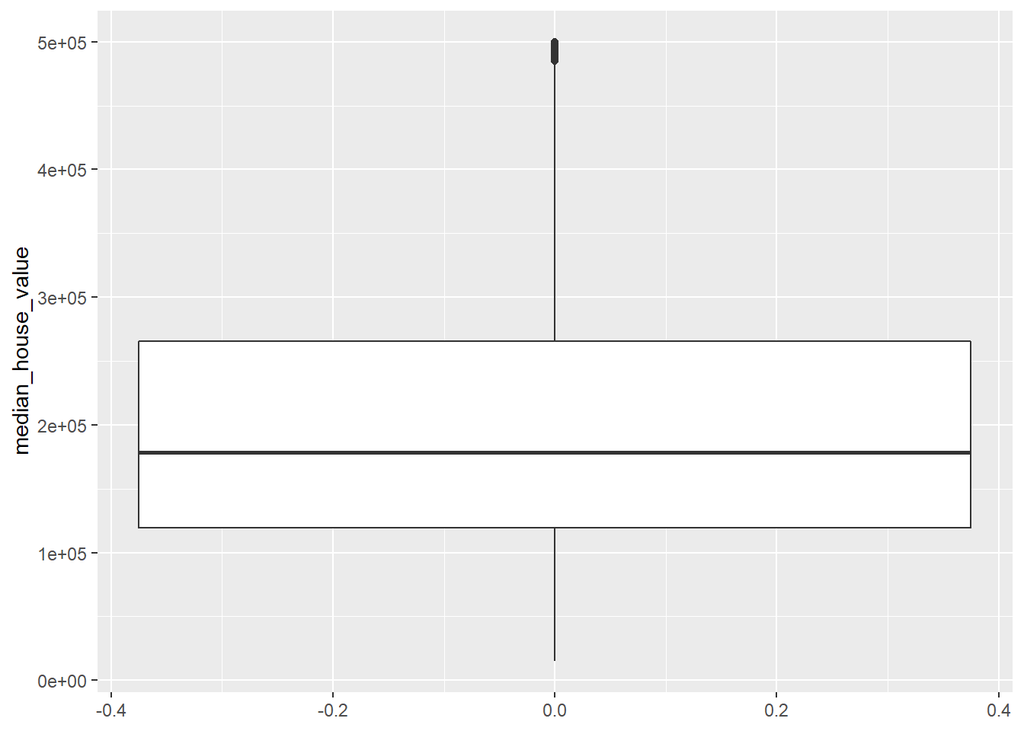

```r
ggplot(house_df, aes(y=median_house_value)) +
  geom_boxplot()
```

total_bedrooms: Segun el Summary esta variable tiene algunos NAs.

```r
house_df <- house_df %>%
  mutate(ocean_proximity = as.factor(ocean_proximity))

house_df_test <-  house_df_test %>%
  mutate(ocean_proximity = as.factor(ocean_proximity))

house_df_comp <-  house_df_comp %>%
  mutate(ocean_proximity = as.factor(ocean_proximity))


summary(house_df$ocean_proximity)
```

```
##  <1H OCEAN     INLAND     ISLAND   NEAR BAY NEAR OCEAN
##       6307       4553          4       1603       1836
```

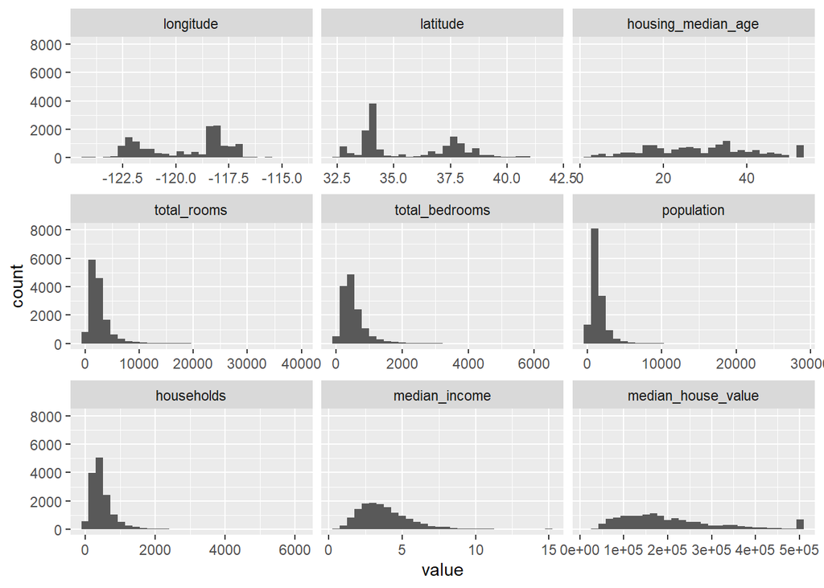

```r
ggplot(data = melt(house_df), mapping = aes(x = value)) +
    geom_histogram(bins = 30) + facet_wrap(~variable, scales = 'free_x')
```

- Existe una porcion de casas que aumenta el histograma del medina_house_value justo en 500K, lo que indica que probablemente hay un limite aplicado a esa variable.
- La escala de las variables varia bastante, es por eso que se aplico un facet_wrap liberando la escala del eje X. Por l que se deberia escalar los valores en el proceso de Feature Engineering.
- El housing_median_age tambien nos muestra que hay algunos bloques con casas ya envejecidas.

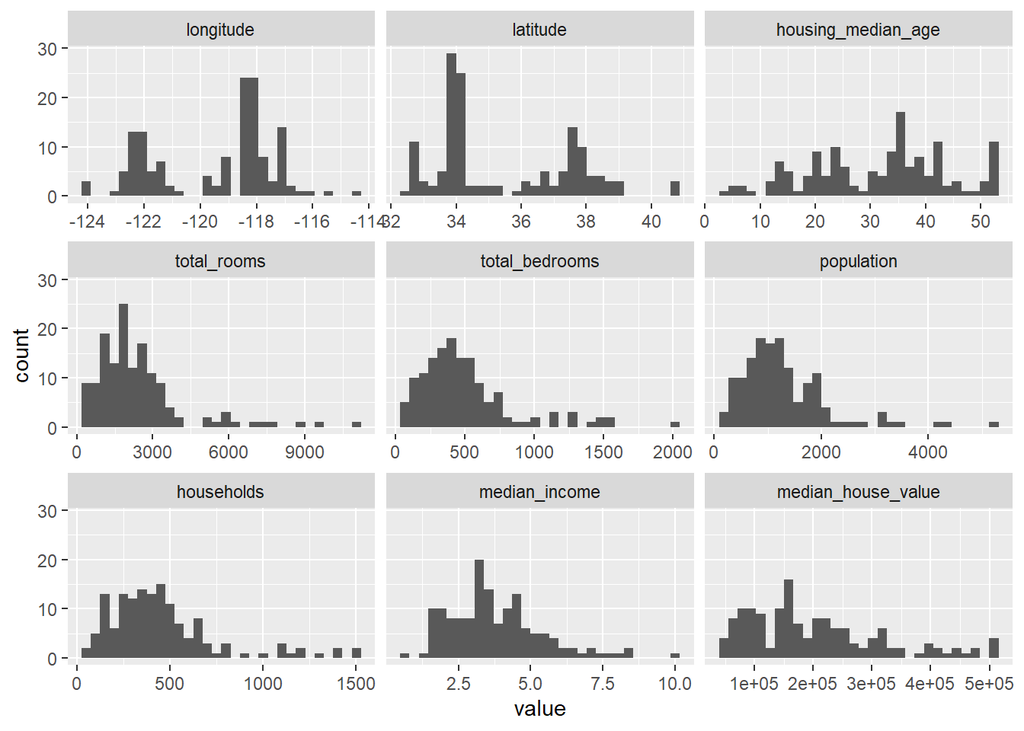

```r
ggplot(data = melt(house_df_test), mapping = aes(x = value)) +
    geom_histogram(bins = 30) + facet_wrap(~variable, scales = 'free_x')
```

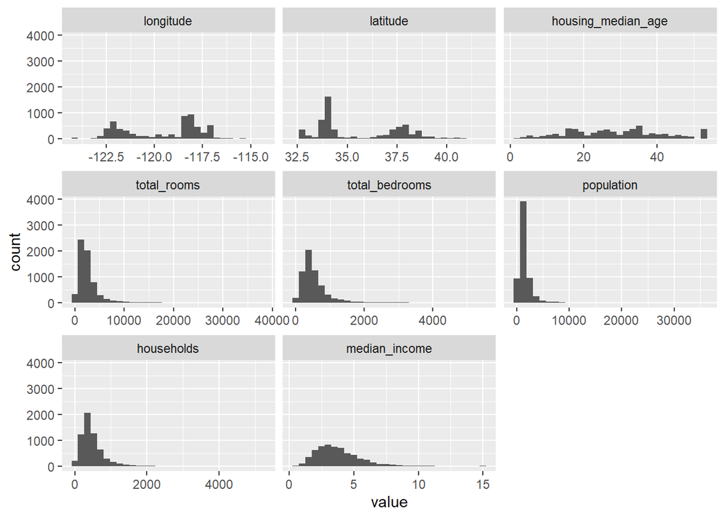

```r
ggplot(data = melt(house_df_comp), mapping = aes(x = value)) +
    geom_histogram(bins = 30) + facet_wrap(~variable, scales = 'free_x')
```

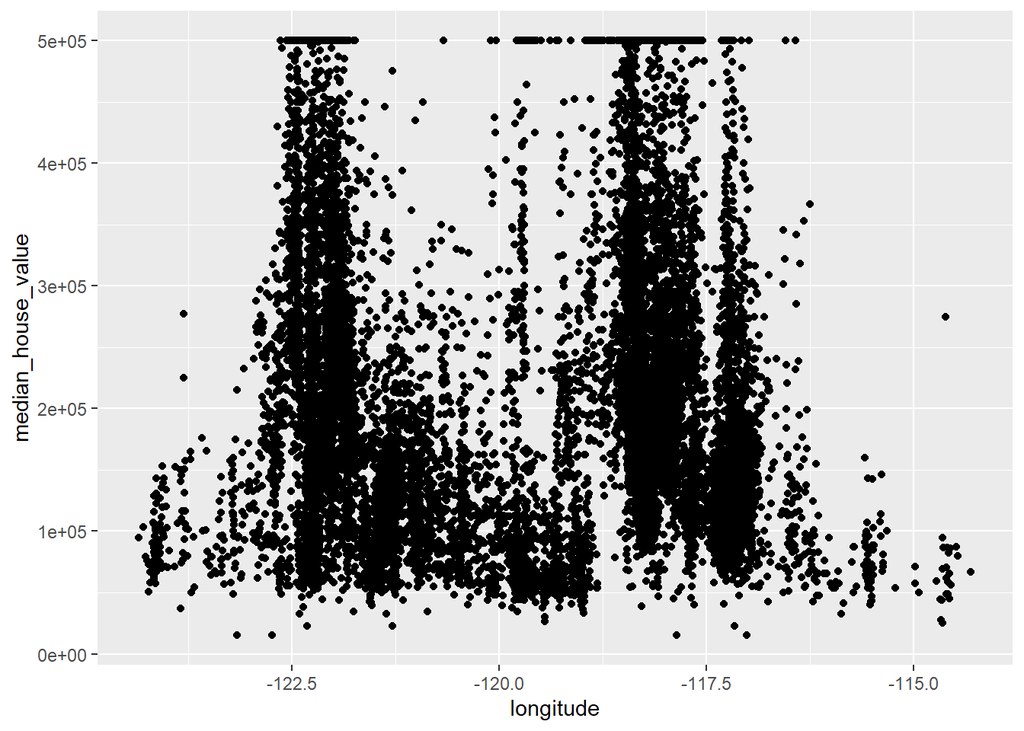

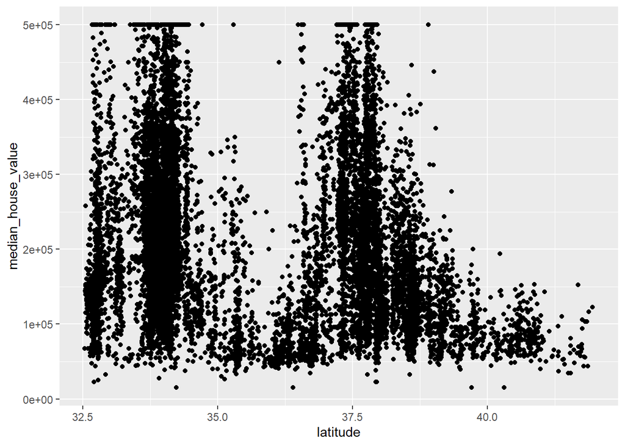

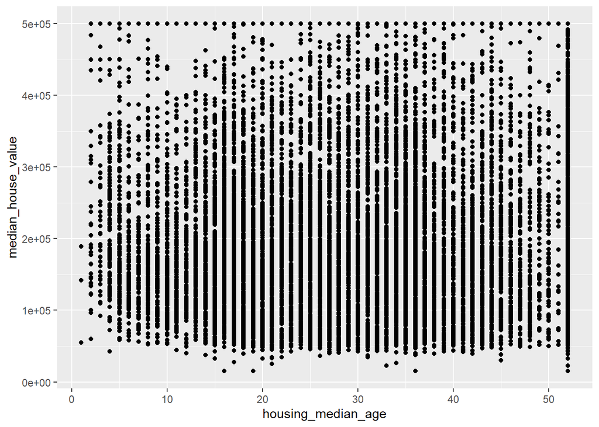

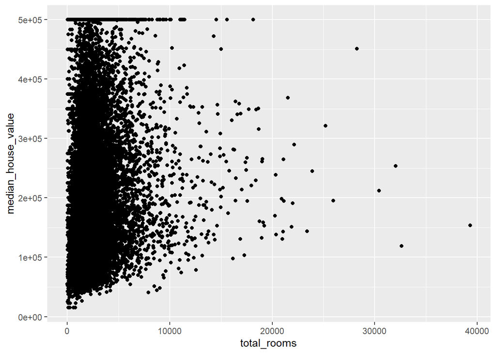

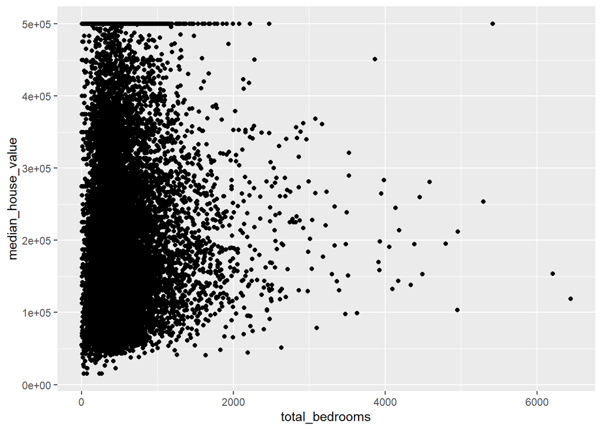

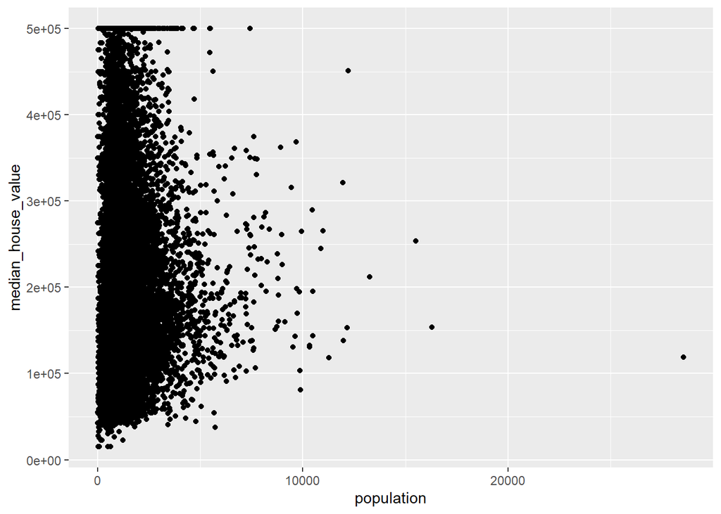

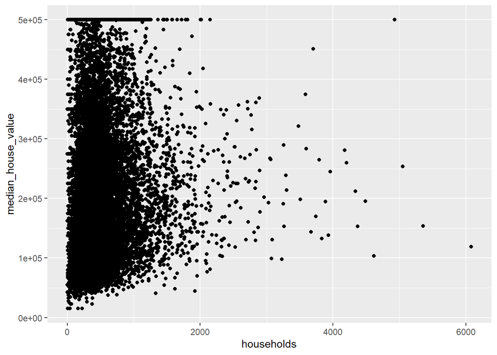

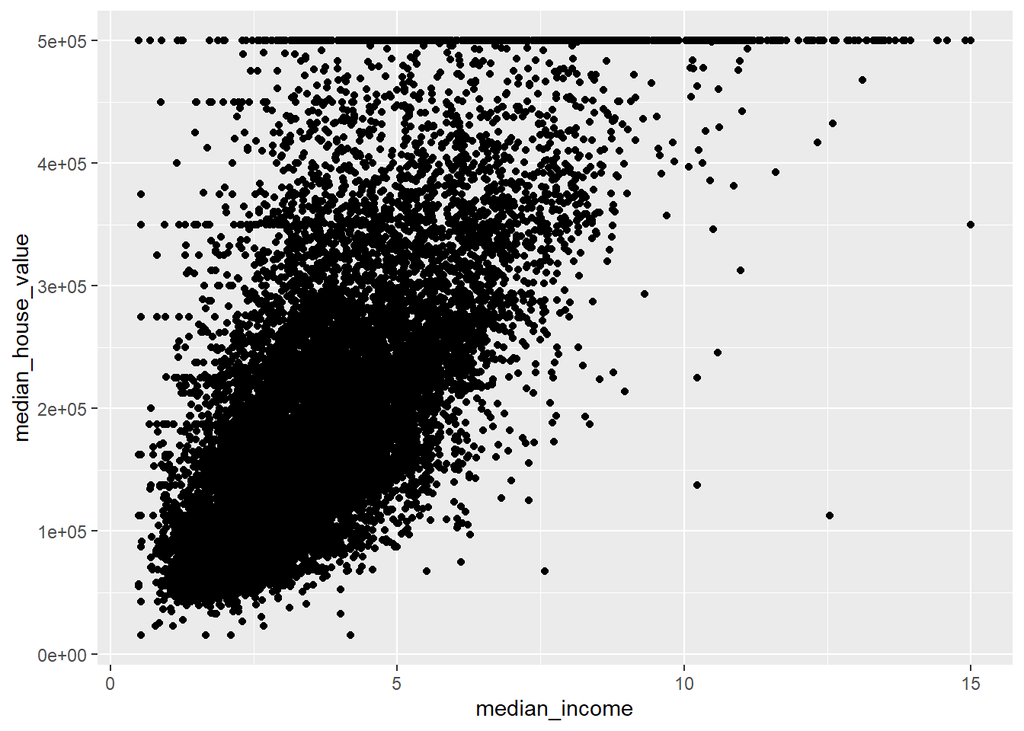

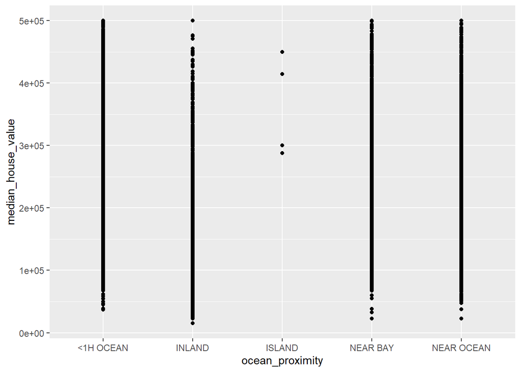

```r
plotAllvsY <- function(df, Y) {
  cols <- colnames(df)[-Y]
  Y.var <- colnames(df)[Y]
  lapply(cols, function(col) eval(parse(text=paste0("ggplot(df, aes(x=",col,", y=",Y.var,")) + geom_point()"))))
}
Y <- which(colnames(house_df)=="median_house_value")
plots <- plotAllvsY(house_df, Y)

plots
```

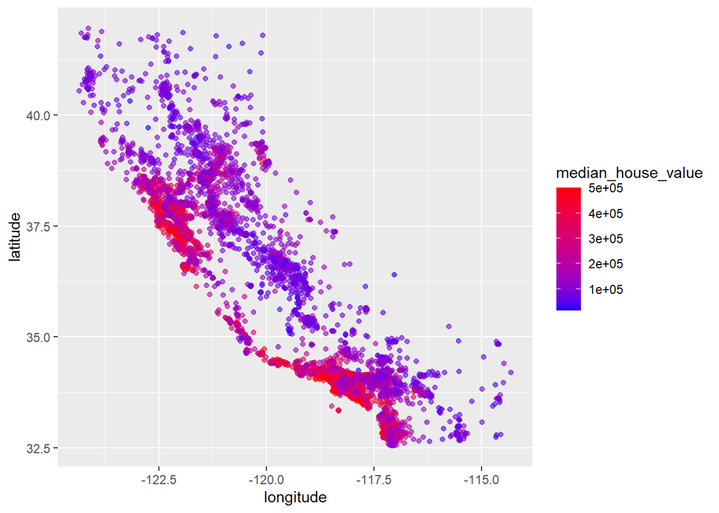

```r
ggplot(house_df, aes(x=longitude, y=latitude, color=median_house_value)) +
  geom_point(alpha=0.6) + scale_color_gradient(low="blue", high="red")
```

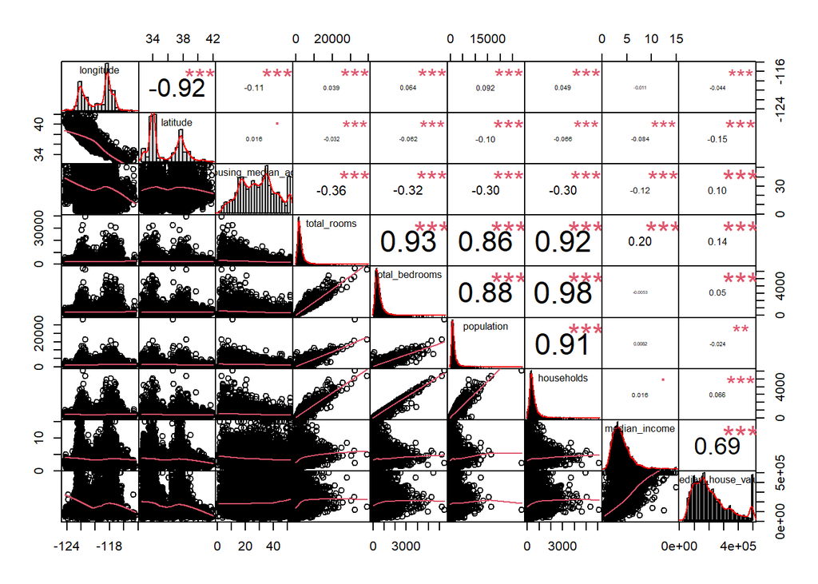

```r
house_df %>% select(-contains("ocean_proximity")) %>%
  chart.Correlation(hist=TRUE)
```

### Imputing Missing Data

```r
colsNA<-colnames(house_df)[!complete.cases(t(house_df))]

dataNA<-house_df %>%
  select(colsNA)
```

[output not shown]

```r
porcentajeNA<-as.data.frame(apply(dataNA, MARGIN = 2, function(col) sum(is.na(col)/length(col))))
colnames(porcentajeNA)<-c("Porcentaje")
porcentajeNA
```

```
##                Porcentaje
## total_bedrooms 0.01006782
```

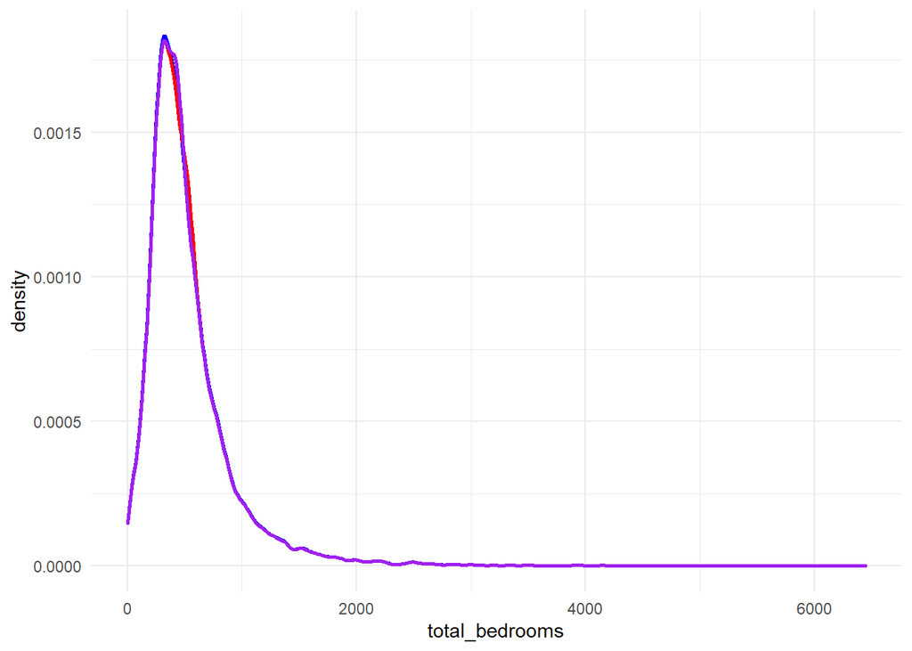

```r
temp <- house_df %>% select(total_bedrooms)
temp$total_bedrooms_media<-ifelse(is.na(temp$total_bedrooms),
                              mean(temp$total_bedrooms, na.rm = TRUE),
                              temp$total_bedrooms)

temp$total_bedrooms_median<-ifelse(is.na(temp$total_bedrooms),
                              median(temp$total_bedrooms, na.rm = TRUE),
                              temp$total_bedrooms)

temp %>%
  ggplot(aes(x=total_bedrooms))+
  geom_density(color="blue", lwd=1)+
  geom_density(aes(x=total_bedrooms_media), color="red", lwd=1) +
  geom_density(aes(x=total_bedrooms_median), color="purple", lwd=1) +
  theme_minimal()
```

```r
dataTemp <- melt(temp)
```

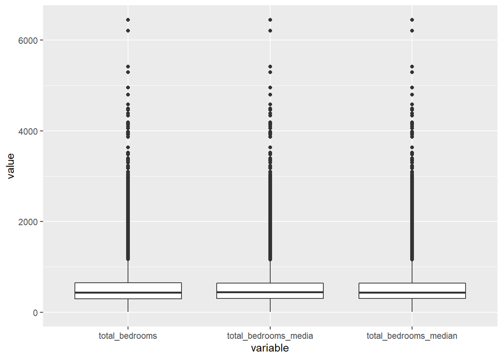

```r
dataTemp %>%
  ggplot(aes(x=variable, y=value))+
  geom_boxplot()
```

```r
house_df$total_bedrooms <- temp$total_bedrooms_median

house_df_test$total_bedrooms <- ifelse(is.na(house_df_test$total_bedrooms),
                              median(house_df_test$total_bedrooms, na.rm = TRUE),
                              house_df_test$total_bedrooms)

house_df_comp$total_bedrooms <- ifelse(is.na(house_df_comp$total_bedrooms),
                              median(house_df_comp$total_bedrooms, na.rm = TRUE),
                              house_df_comp$total_bedrooms)
```

### New Variables

```r
 house_df <- house_df %>%
   mutate(
     bedrooms_rooms_ratio = total_bedrooms / total_rooms,
     bedrooms_per_household = total_bedrooms / households,
     rooms_per_household = total_rooms / households,
     pop_per_household = population / households,
     bedrooms_pop_ratio = total_bedrooms / population,
     extra_rooms_ratio = (total_rooms - total_bedrooms)/population
     )

 house_df_test <- house_df_test %>%
   mutate(
     bedrooms_rooms_ratio = total_bedrooms / total_rooms,
     bedrooms_per_household = total_bedrooms / households,
     rooms_per_household = total_rooms / households,
     pop_per_household = population / households,
     bedrooms_pop_ratio = total_bedrooms / population,
     extra_rooms_ratio = (total_rooms - total_bedrooms)/population
     )


  house_df_comp <- house_df_comp %>%
   mutate(
     bedrooms_rooms_ratio = total_bedrooms / total_rooms,
     bedrooms_per_household = total_bedrooms / households,
     rooms_per_household = total_rooms / households,
     pop_per_household = population / households,
     bedrooms_pop_ratio = total_bedrooms / population,
     extra_rooms_ratio = (total_rooms - total_bedrooms)/population
     )
```

### Correlation

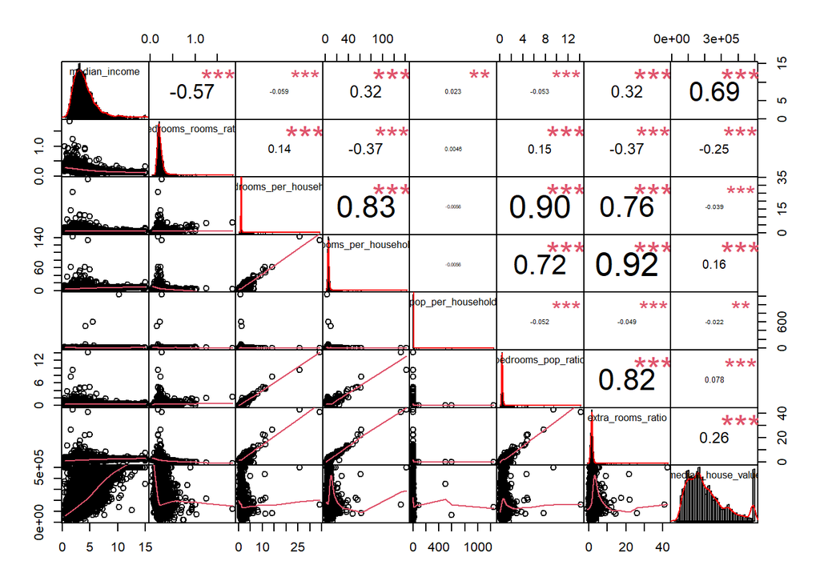

```r
house_df %>% select(median_income, bedrooms_rooms_ratio, bedrooms_per_household, rooms_per_household, pop_per_household, bedrooms_pop_ratio, extra_rooms_ratio, median_house_value) %>%
  chart.Correlation(hist=TRUE)
```

```r
correlation <- house_df %>% select(-ocean_proximity) %>% cor(y =house_df$median_house_value)
rows_n <- rownames(correlation)
corr_df <- data.frame(Correlation=correlation, row.names = rows_n)
corr_df %>% arrange(desc(abs(Correlation)))
```

```
##                        Correlation
## median_house_value      1.00000000
## median_income           0.69063744
## extra_rooms_ratio       0.26070144
## bedrooms_rooms_ratio   -0.24715744
## rooms_per_household     0.15945372
## latitude               -0.14546822
## total_rooms             0.13767357
## housing_median_age      0.10477047
## bedrooms_pop_ratio      0.07810512
## households              0.06613432
## total_bedrooms          0.04947948
## longitude              -0.04442750
## bedrooms_per_household -0.03930015
## population             -0.02440875
## pop_per_household      -0.02180147
```

De los terminos derivados podemos observar que `extra_rooms_ratio` esta mas correlacion con el valor de la casa que las variables de las que se deriva. Esto tiene sentido al considerar que casas con mas cuartos que no son solo cuartos para dormir podrian considerarse como cuartos de entretenimiento o estudios. Extras que harian que una casa aunmentase su valor. Este termino de interaccion mejor incluso la correlacion de cuartos por hogar `rooms_per_household` y la proporcion de dormitorios por cuartos en el bloque `bedrooms_rooms_ratio`.

### Categorical Variables - OHE K-1

```r
categorical_cols <- colnames(house_df)[sapply(house_df, is.factor)]
categorical_cols
```

```
## [1] "ocean_proximity"
```

```r
dataset <- house_df %>%
                select(all_of(categorical_cols))

sapply(dataset,levels)
```

```
##      ocean_proximity
## [1,] "<1H OCEAN"
## [2,] "INLAND"
## [3,] "ISLAND"
## [4,] "NEAR BAY"
## [5,] "NEAR OCEAN"
```

```r
apply(dataset, 2, table)
```

```
##            ocean_proximity
## <1H OCEAN             6307
## INLAND                4553
## ISLAND                   4
## NEAR BAY              1603
## NEAR OCEAN            1836
```

Vemos que la clase Island tiene una poca frecuencia. Por ello aplicamos OHE K-1 removiendo esta clase.

```r
dataset <- house_df %>%
                select(all_of(categorical_cols))
# El valor Island es candidato a eliminarse en OHE K-1
OHE <- dummyVars("~.", data = dataset)
OHE_dataframe<-data.frame(predict(OHE, newdata = dataset))
house_df <- cbind(OHE_dataframe, house_df) %>%
  select(-c("ocean_proximity", "ocean_proximity.ISLAND"))

dataset <- house_df_test %>%
                select(all_of(categorical_cols))

OHE_dataframe<-data.frame(predict(OHE, newdata = dataset))
house_df_test <- cbind(OHE_dataframe, house_df_test) %>%
  select(-c("ocean_proximity", "ocean_proximity.ISLAND"))

dataset <- house_df_comp %>%
                select(all_of(categorical_cols))


OHE_dataframe<-data.frame(predict(OHE, newdata = dataset))
house_df_comp <- cbind(OHE_dataframe, house_df_comp) %>%
  select(-c("ocean_proximity", "ocean_proximity.ISLAND"))
```

## Treat Outlieers

```r
df <- house_df %>%
  select(-contains('.'))

cols <- colnames(df)

x <- sapply(cols, function(col) detect_outliers(df, col))
```

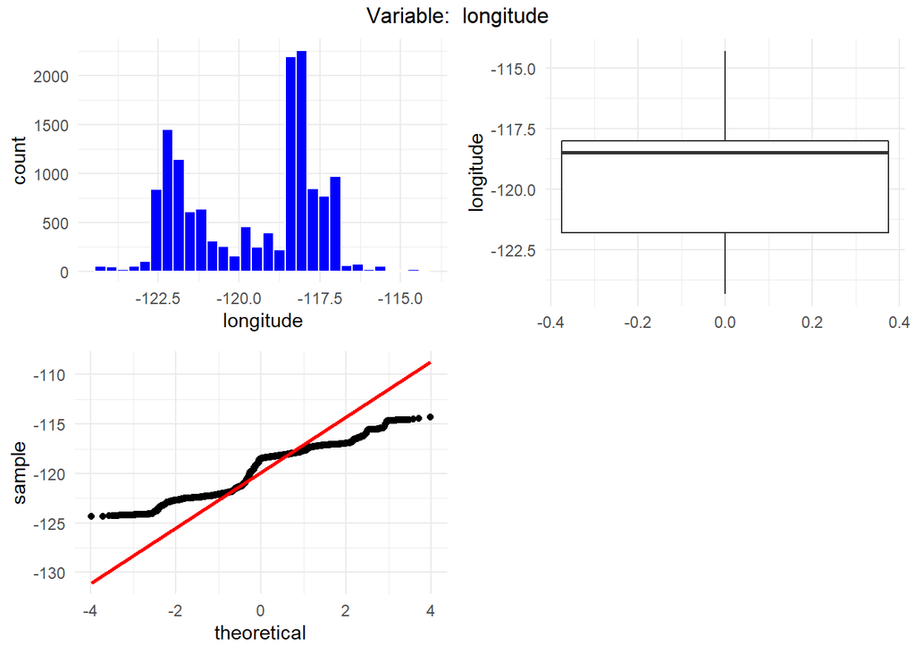

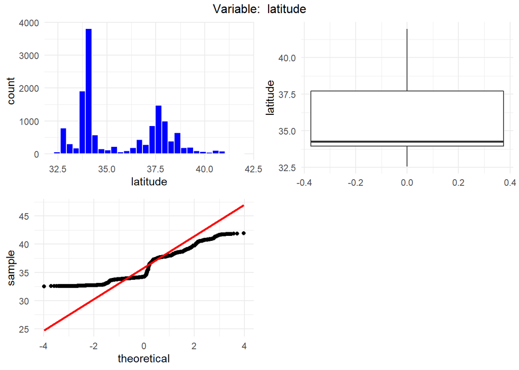

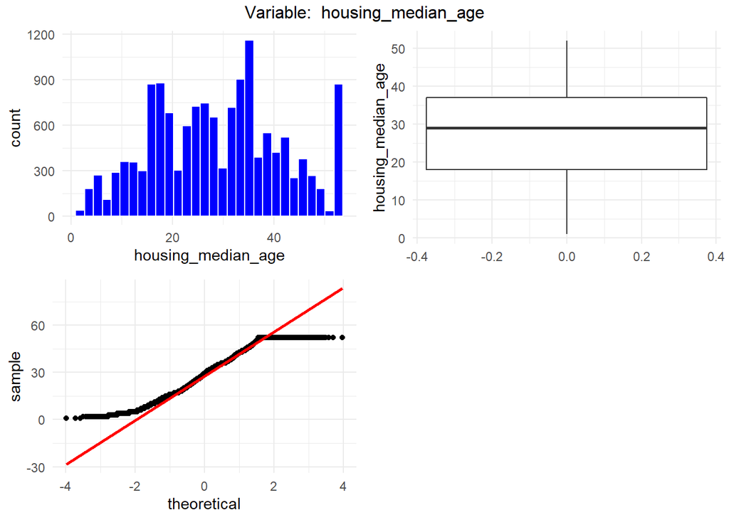

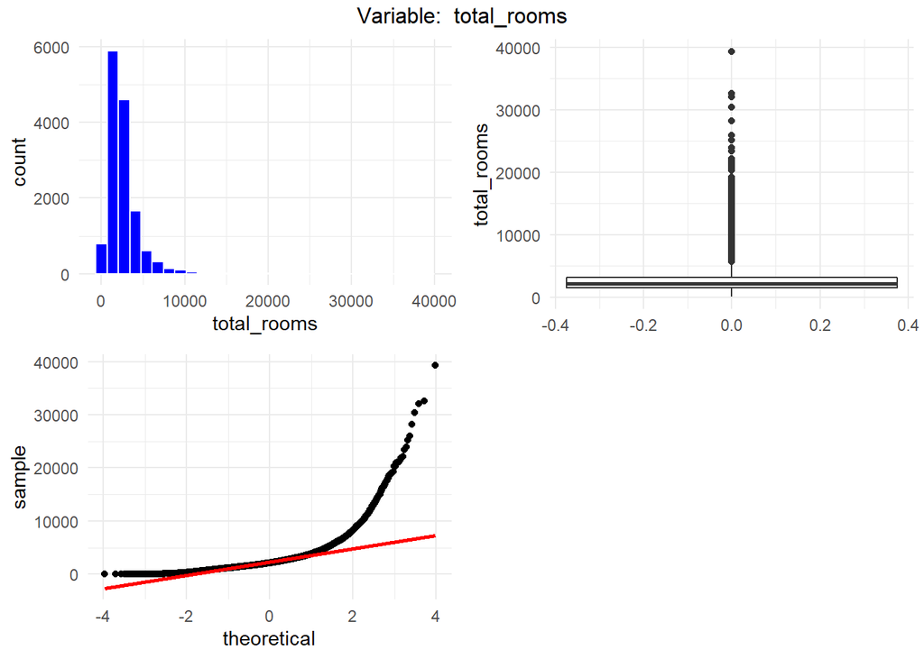

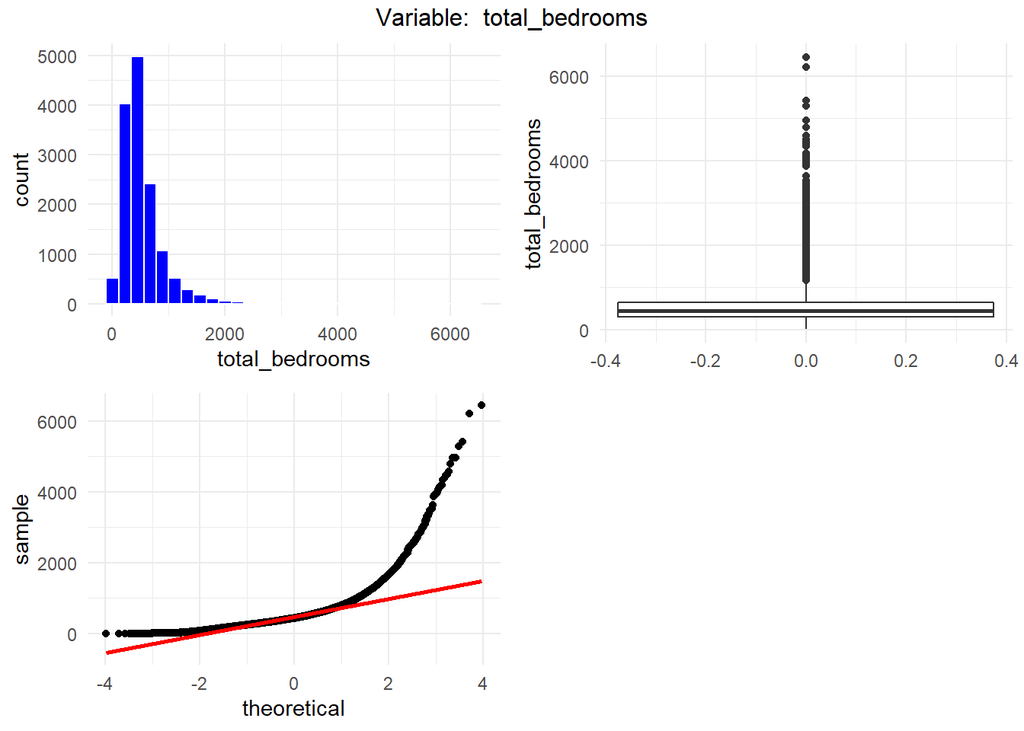

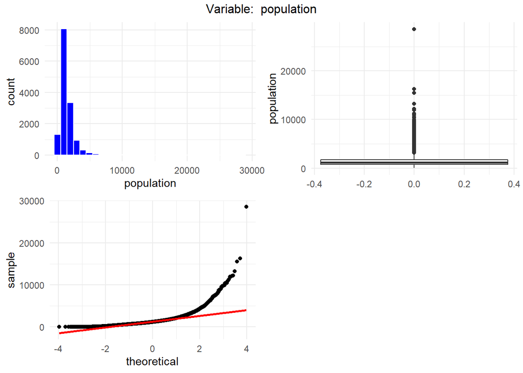

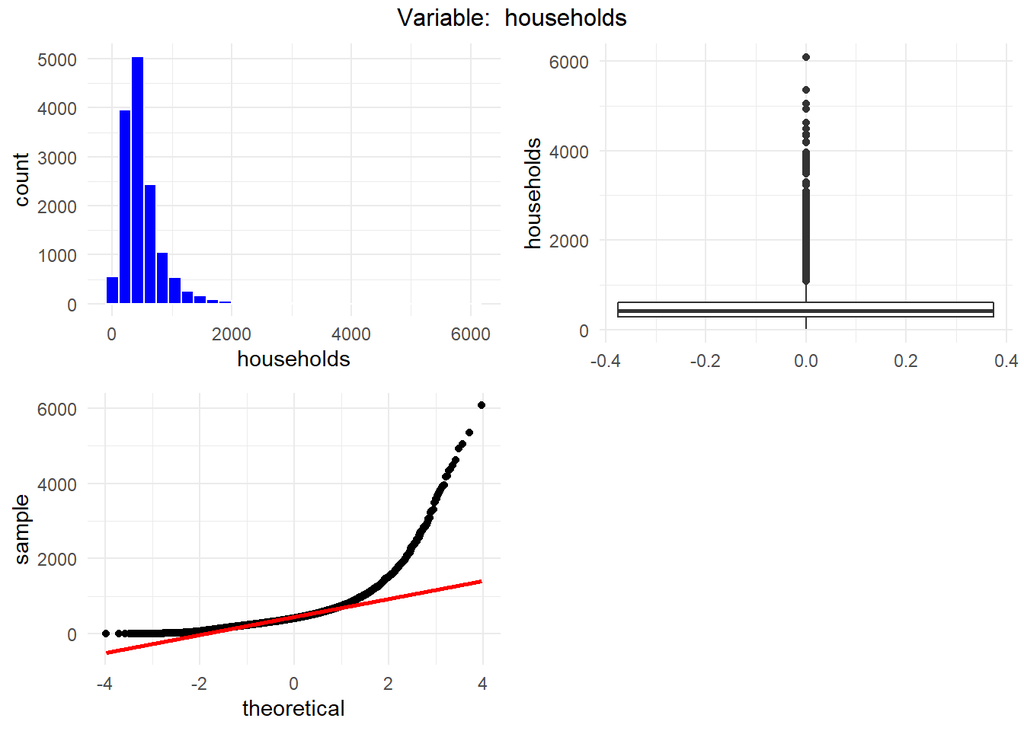

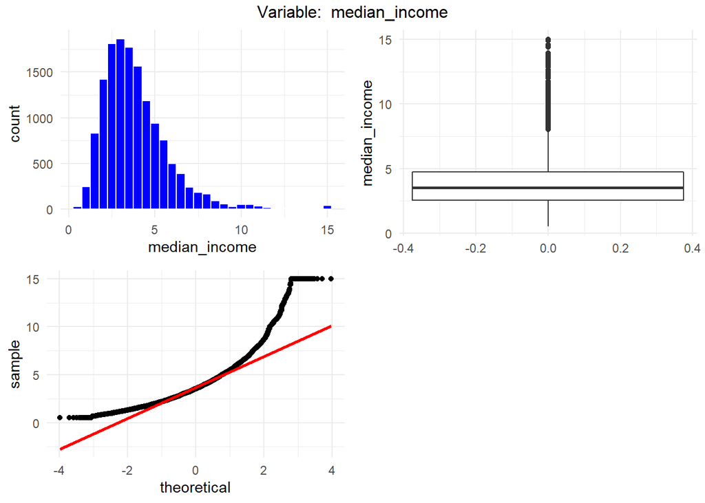

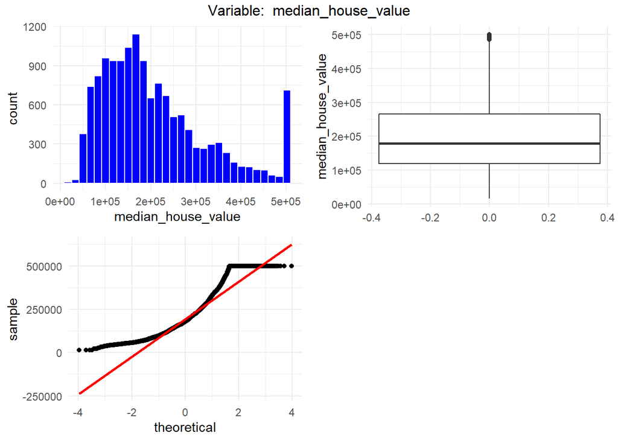

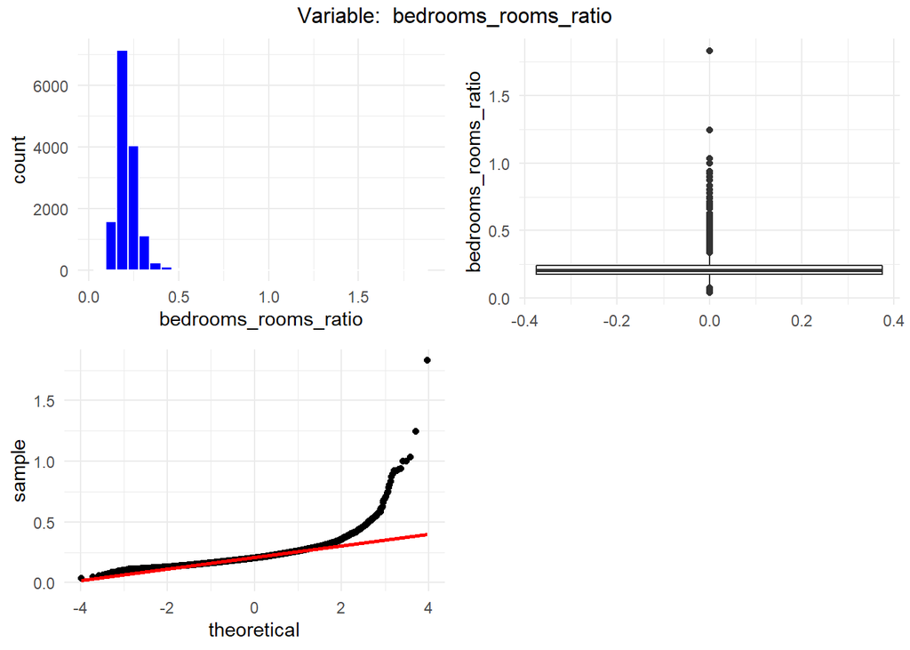

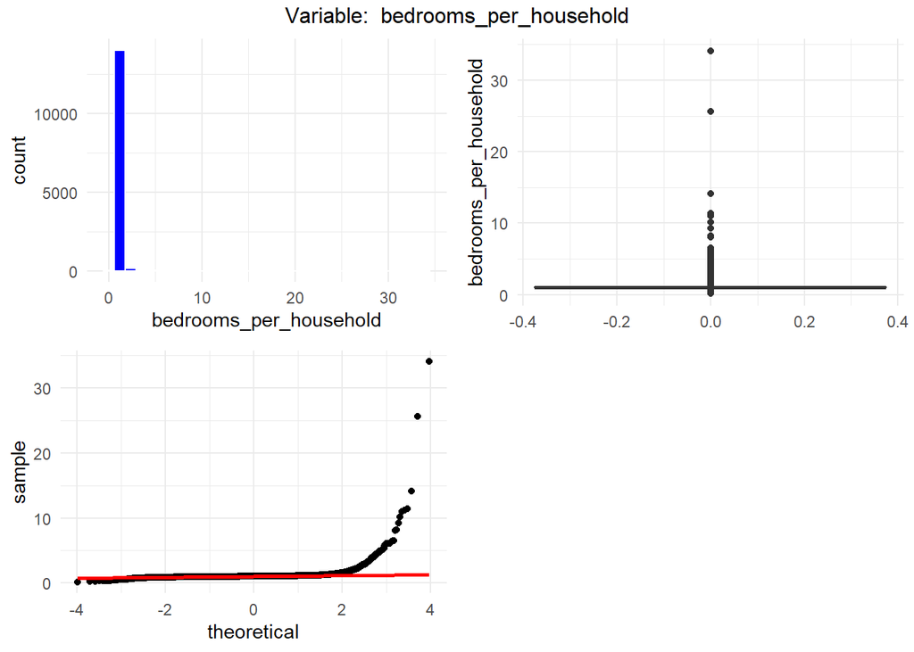

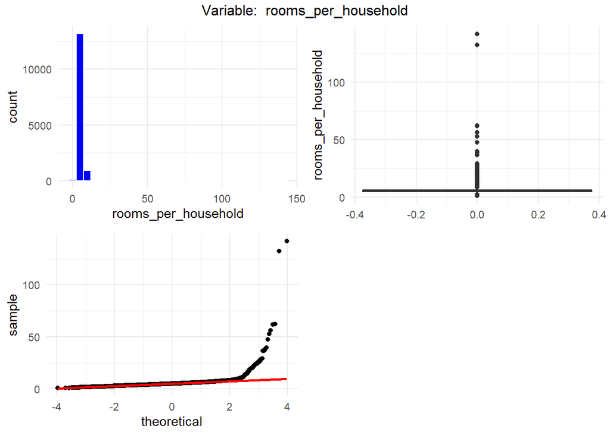

[3 more figures not shown]

```r
# house_df[, cols] <- as.data.frame(sapply(cols, function(col) apply_capping(df, col)))
# x <- sapply(cols, function(col) detect_outliers(house_df, col))
```